# Модели со случайными факторами

## Линейные модели, осень 2014

Марина Варфоломеева  
Каф. Зоологии беспозвоночных, СПбГУ

## Модели со случайными факторами

- Фиксированные и случайные факторы
- Смешанные модели
- Типы данных, для которых нужны смешанные модели
- Как устроена смешанная линейная модель?
- Оценка параметров смешанных линейных моделей

### Вы сможете

- Рассказать чем фиксированные факторы отличаются от случайных
- Привести примеры факторов, которые могут быть фиксированными или случайными в зависимости от задачи исследования
- Привести примеры планов экспериментов со случайными факторами
- Рассказать, что оценивает коэффициент внутриклассовой корреляции и вычислить его для случая с одним случайным фактором
- Подобрать смешанную линейную модель в R при помощи методов максимального правдоподобия

# Фиксированные и случайные факторы

#

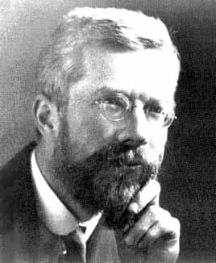

В дисперсионном анализе, как его придумал Фишер, не делалось различий между разными типами факторов

- факторы влияют на различия внутригрупповых средних

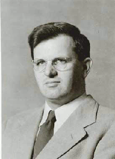

Черчилль Эйзенхарт (1947) первый заметил различие между фиксированными и случайными факторами.

- **фиксированные эффекты** - влияют на различия внутригрупповых средних \(y\)
- **случайные эффекты** - влияют на различия внутригрупповых дисперсий \(y\)

## Фиксированные и случайные факторы

### Фиксированные факторы

- Одна страна по сравнению с другой
- Пол
- Добавили удобрение или нет
- Низина или вершина
- Илистый или песчаный грунт
- Тень или свет
- Один возраст по сравнению с другим

### Случайные факторы

- Выводок
- Блок на участке литорали
- Делянка на участке
- Особь с повторными измерениями
- Аквариум в лабораторном эксперименте

## Фиксированные и случайные факторы

### Фиксированные факторы

- Градации фактора - фиксированные, заранее определенные и потенциально воспроизводимые уровни этого фактора (даже если и не все).
- Используются для тестирования гипотез о том, что средние значения зависимой переменной различаются в группах по фактору

\[H _{0}: μ _1 = μ _2 = · · · = μ _i = μ\]

- Выводы можно экстраполировать только на такие уровни, которые были задействованы в анализе

### Случайные факторы

- Градации фактора - случайная выборка из возможных уровней этого фактора, повторить такой же набор градаций невозможно.
- Используются для тестирования гипотез о том, что с группировкой по фактору связана некоторая доля общей дисперсии

\[H _{0}: σ _α^2 = 0\]

- Выводы можно экстраполировать на все возможные уровни фактора

## Какого типа эти факторы? От чего это зависит?

- Несколько произвольно выбранных градаций плотности моллюсков в полевом эксперименте, где плотностью манипулировали.
- Фактор размер червяка (маленький, средний, большой) в выборке червей.
- Деление губы Чупа на зоны с разной степенью распреснения.
- Может ли один и тот же фактор рассматриваться как случайный или фиксированный?
- Приведите примеры, как тип фактора будет зависеть от проверяемых гипотез

# Смешанные модели - содержат фиксированные и случайные факторы одновременно

## Псевдорепликация - нарушение независимости наблюдений

- Если есть временной ряд наблюдений
- Если пробы расположены рядом
- Если пробы/измерения взяты с одного объекта

Если такие данные проанализировать, как будто все наблюдения независимы, произойдет псевдорепликация

Можно усреднить значения между псевдоповторностями, а можно применить смешанные модели

### Типы данных, для которых нужны смешанные модели

- blocking designs
- nested
- repeated measures & longitudinal data

## Полностью рандомизированный план (completely-randomised)

Для этого варианта не нужны смешанные модели

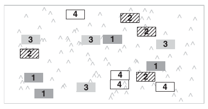

Экспериментальные единицы распределены по тритментам полностью случайно.

Нет псевдорепликации

## Случайный блочный план (complete block design)

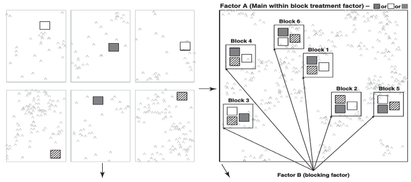

полностью рандомизированный план

случайный блочный план

Экспериментальные единицы объединены в блоки. И внутри блоков случайным образом распределены по тритментам

Наблюдения внутри одного блока похожи

## Вложенный план (nested design)

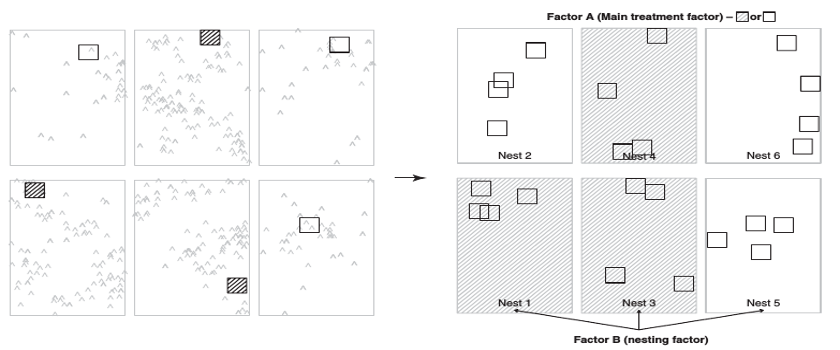

Полностью рандомизированный план

Вложенный план

Группы экспериментальных единиц случайно распределены по тритментам. Внутри группы сделано несколько измерений.

## Повторные измерения в пространстве и во времени

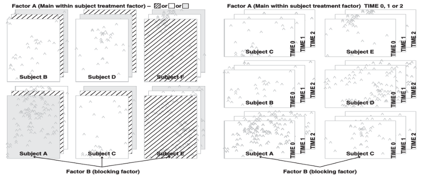

План с повторными измерениями в пространстве

Внутри каждого блока в пространстве делается несколько измерений

План с повторными измерениями во времени

На каждом субъекте делается несколько измерений

## Планы с ращепленными делянками и сложный план с повторными измерениями

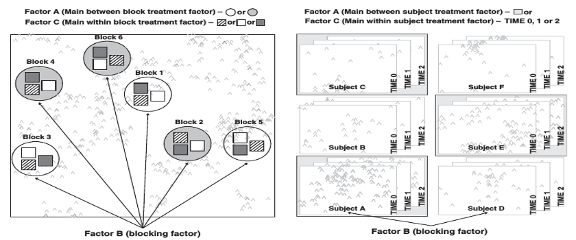

План с ращепленными делянками

План с повторными измерениями

Субъекты (единицы) случайным образом распределены по тритментам, на каждом субъекте делается несколько измерений

## Структура ковариаций при различных эксп. планах

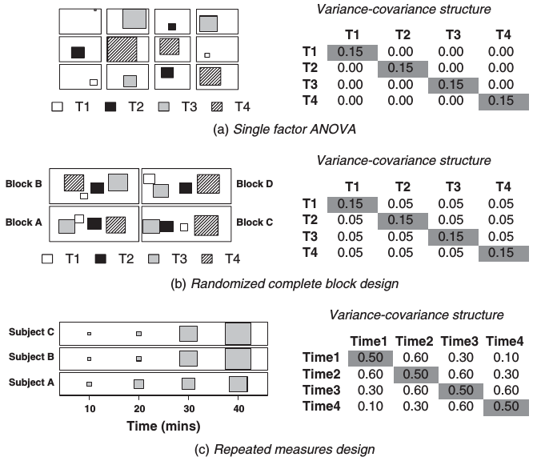

# Как устроена смешанная линейная модель?

## Смешанная линейная модель

\[Y_i = X _i \times \beta + Z_i \times b _i + \epsilon _i\]

\(b _i \sim N(0, D)\) - случайные эффекты нормально распределены со средним 0 и дисперсией D

\(\epsilon _i \sim N(0, \Sigma _i)\) - остатки модели нормально распределены со средним 0 и дисперсией \(\Sigma _i\)

\(X _i \times \beta\) - фиксированная часть модели

\(Z_i \times a _i\) - случайная часть модели

## В примере модель можно записать так:

в матричном виде это записываеться:

\[ \left( \begin{array}{c} R _{i1} \\ R _{i2} \\ R _{i3} \\ R _{i4} \\ R _{i5} \end{array} \right) = \left(\begin{array}{cc} 1 & NAP _{i1} \\ 1 & NAP _{i2}\\ 1 & NAP _{i3}\\ 1 & NAP _{i4}\\ 1 & NAP _{i5} \end{array} \right) \times \left( \begin{array}{c} \beta _0 \\ \beta _1 \end{array} \right) + \left( \begin{array}{c} 1 \\ 1 \\ 1 \\ 1 \\ 1 \end{array} \right) \times b _{i} + \left( \begin{array}{c} \epsilon _{i1} \\ \epsilon _{i2}\\ \epsilon _{i3}\\ \epsilon _{i4}\\ \epsilon _{i5} \end{array} \right)\]

что можно записать сокращенно так:

\[R _i = X _i \times \beta + Z _i \times b _i\]

## Теперь разберемся с допущениями

\(b _i \sim N(0, d^2)\) - случайные эффекты \(b _i\) нормально распределены со средним 0 и дисперсией \(d^2\)

\(\epsilon _i \sim N(0, \Sigma _i)\) - остатки модели нормально распределены со средним 0 и матрицей ковариаций \(\Sigma _i\)

Матрица ковариаций остатков выглядит так: \[\Sigma _i = \sigma^2 \times \left( \begin{array}{ccccc} 1 & 0 & \cdots & \cdots & 0 \\ 0 & 1 & 0 & \cdots & \vdots \\ \vdots & 0 & 1 & 0 & \vdots \\ \vdots & \vdots & 0 & 1 & 0 \\ 0 & \cdots & \cdots & 0 & 1 \end{array} \right)\]

Т.е. остатки независимы друг от друга (вне диагонали стоят нули, т.е. ковариация разных остатков 0).

В то же время, отдельные значения \(Y_i\) уже не будут независимы друг от друга при добавлении случайных эффектов - см. ниже

Можно показать, что \(Y _i\) нормально распределена \(Y _i \sim N(X _i \times \beta, V _i)\)

\(V _i = Z _i × D × Z' _i + \Sigma _i\) - матрица ковариаций зависимой переменной

\(D\) - матрица ковариаций случайных эффектов.

Т.е. **добавление случайных эффектов приводит к изменению ковариационной матрицы** \(V _i\)

Для модели со случайным intercept:

\[ V _i = \left( \begin{array}{c} 1 \\ 1 \\ 1 \\ 1 \\ 1 \end{array}\right) \times d^2 \times \left( \begin{array}{c} 1 & 1 & 1 & 1 & 1 \end{array}\right) + \sigma^2 \times \left( \begin{array}{ccccc} 1 & 0 & \cdots & \cdots & 0 \\ 0 & 1 & 0 & \cdots & \vdots \\ \vdots & 0 & 1 & 0 & \vdots \\ \vdots & \vdots & 0 & 1 & 0 \\ 0 & \cdots & \cdots & 0 & 1 \end{array} \right) = \] \[ = \left( \begin{array}{ccccc} \sigma^2 + d^2 & d^2 & d^2 & d^2 & d^2 \\ d^2 & \sigma^2 + d^2 & d^2 & d^2 & d^2 \\ d^2 & d^2 & \sigma^2 + d^2 & d^2 & d^2 \\ d^2 & d^2 & d^2 & \sigma^2 + d^2 & d^2 \\ d^2 & d^2 & d^2 & d^2 & \sigma^2 + d^2 \end{array} \right) \]

## Индуцированная корреляция - следствие включения в модель случайных эффектов

\[ V_i = \left( \begin{array}{ccccc} \sigma^2 + d^2 & d^2 & d^2 & d^2 & d^2 \\ d^2 & \sigma^2 + d^2 & d^2 & d^2 & d^2 \\ d^2 & d^2 & \sigma^2 + d^2 & d^2 & d^2 \\ d^2 & d^2 & d^2 & \sigma^2 + d^2 & d^2 \\ d^2 & d^2 & d^2 & d^2 & \sigma^2 + d^2 \end{array} \right) \]

\(d^2\) - ковариация между пробами с одного пляжа; \(\sigma^2 + d^2\) - дисперсия

Т.е. корреляция между пробами с одного пляжа будет \(d^2 / (\sigma^2 + d^2)\)

### Коэффициент внутриклассовой корреляции \(d^2 / (\sigma^2 + d^2)\)

Способ измерить, насколько коррелируют друг с другом наблюдения из одной и той же группы случайного фактора

Следствие: Если он высок, то можно брать меньше проб в группе (и больше групп, если нужно)

## Структура ковариаций при различных эксп. планах

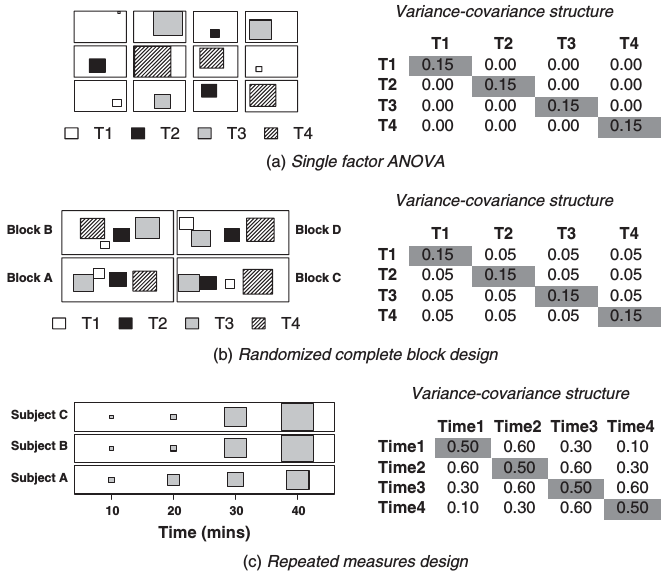

# Оценка параметров смешанных линейных моделей

## Оценка параметров методом максимального правдоподобия

- Метод максимального правдоподобия (maximum likelihood, ML)
- Метод ограниченного максимального правдоподобия (restricted maximum likelihood, ML)
  - лучшие оценки параметров
  - возможность работать с несбалансированными группами
  - моделируют внутригрупповую структуру корреляций (сходство наблюдений внутри групп по случайному фактору)
  - можно получить доверительные интервалы параметров (интервалы, в которых окажется значение параметра при анализе похожих данных в p% случаев)

## Байесовские методы оценки параметров

- Марковские цепи Монте Карло (Markov chain Monte Carlo, MCMC)
  - Марковские цепи позволяют получить апостериорные распределения параметров
  - Выборки из этих распределений можно использовать для построения p% байесовских доверительных интервалов (интервалы, в которых с p% вероятностью находится истинное значение параметра)

## Синтаксис задания моделей в R

**Фиксированная часть модели** задается двухсторонней формулой

`fixed = y ~ 1`

Вложенные друг в друга эффекты указываются от крупного к мелкому через "/"

`random = ~ 1|a/b/c`

**Два пакета в r**, каждый со своим синтаксисом

- `lme()` из пакета `nlme`

`lme(fixed = y ~ 1, random = ~ 1|a/b/c)`

- `lmer()` из пакета `lme4`

`lmer(y ~ 1 + (1|a/b/c))`, если уровни вложенных факторов повторяются в группах более крупных факторов

`lmer(y ~ 1 + (1|a) + (1|b) + (1|c))`, если уровни вложенных факторов имеют уникальные названия

## Take home messages

- Смешанные модели включают случайные и фиксированные факторы
- Градации фиксированных факторов заранее определены, а выводы можно экстраполировать только на такие уровни, которые были задействованы в анализе. Тестируется гипотеза о значении средних
- Градации случайных факторов - выборка из возможных уровней, а выводы можно экстраполировать на другие уровни. Тестируется гипотеза о дисперсии между группами по фактору.
- Коэффициент внутриклассовой корреляции оценивает, насколько коррелируют друг с другом наблюдения из одной и той же группы случайного фактора
- Параметры смешанных моделей подбирают методами максимального правдоподобия или байесовскими методами.

## Дополнительные ресурсы

- Crawley, M.J. (2007). The R Book (Wiley).
- Zuur, A.F., Ieno, E.N., Walker, N., Saveliev, A.A., and Smith, G.M. (2009). Mixed Effects Models and Extensions in Ecology With R (Springer).